# Climate Trends: Seattle, Washington

Lucas Boyd and Max Settineri

4/5/2022

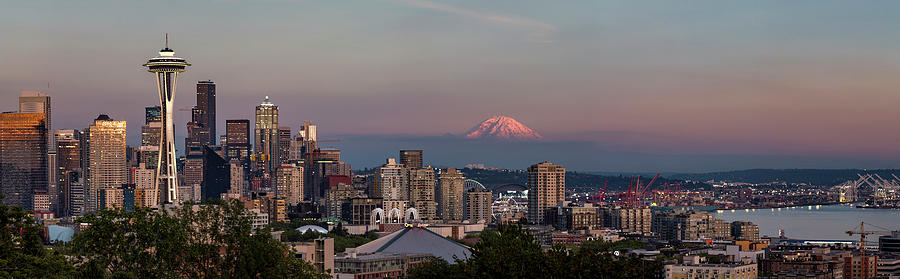

Seattle’s downtown skyline. Credit: *Adam Romanowicz*

# Overview

Seattle is the largest city in Washington State. Situated between the Puget Sound and Lake Washington, it is a largely urban area that is home to nearly 730,000 people. Known for its mild weather and persistent rain, Seattle’s climate is temperate, which until recently has meant that it has avoided extreme temperature events, has abundant fresh water, and is famous for its lush green foliage. However, June of 2021 saw many of the hottest days in Seattle’s history. Moreover, wildfires have become increasingly common in over the past decade. Together, these troubling trends raise questions about how Seattle’s climate is changing and what adaptation measures should be implemented to adapt to these changes. The following report analyzes climate trends in Seattle using daily climate data from the National Climatic Data Center (NCDC). First, average climate variables relating to temperature and precipitation are explored to discover how Seattle’s climate has changed from 1949 until today. Then, frequency and severity of climate extremes are examined.

## Setup

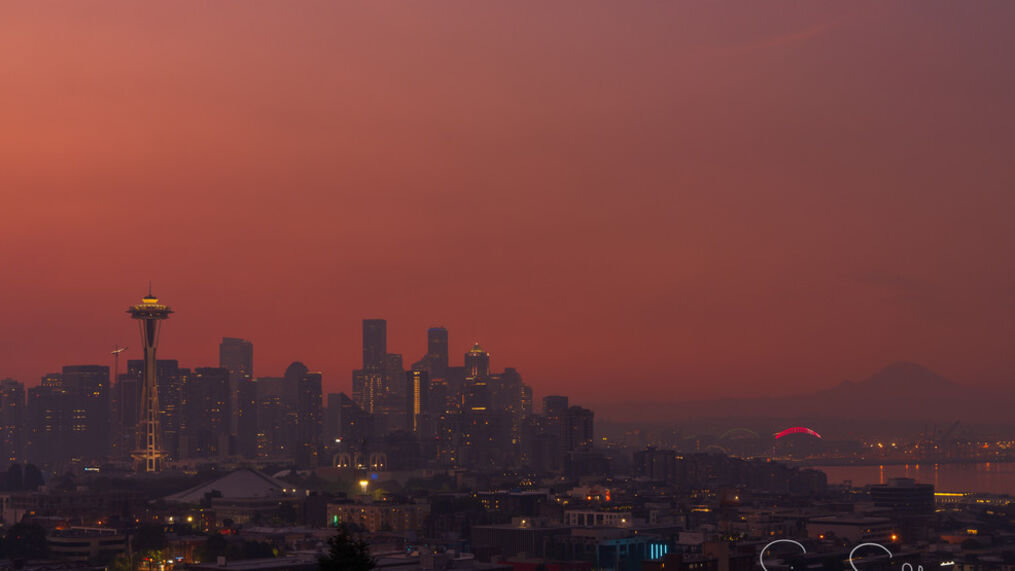

Wildfire smoke blankets the city. Credit: *Komo 4 News*

```r
knitr::opts_chunk$set(echo = TRUE, message = FALSE, warning = FALSE)

library(here)
library(tidyverse)
library(janitor)
library(lubridate)
library(tsibble)
library(feasts)
library(gghighlight)
library(plotly)
library(Kendall)
library(kableExtra)
library(broom)
```

### Data

**Citation:** Climate Data Online (CDO). “National Climatic Data Center (NCDC).” Accessed April 8, 2022. https://www.ncdc.noaa.gov/cdo-web/datasets#GHCND.

```r
seattle <- read_csv(here("data", "seattle.csv")) %>%
  clean_names() %>%
  select(-station, -name, -starts_with("wt")) %>%
  mutate(month = month(date, label = TRUE)) %>%
  mutate(year = year(date)) %>%
  drop_na(tmax, tmin, prcp)
```

## Climate Averages

```r
# data wrangling

# converting the dataframe to a time series
seattle_ts <- seattle %>%
  as_tsibble(key = NULL, index = date)

# monthly summary statistics
seattle_monthly <- seattle_ts %>%
  index_by(year_month = ~yearmonth(.)) %>%
  summarize(mean_daily_max_temp = mean(tmax, na.rm = TRUE),
            mean_daily_min_temp = mean(tmin, na.rm = TRUE),
            mean_daily_precip = mean(prcp, na.rm = TRUE),
            max_temp_monthly = max(tmax, na.rm = TRUE),
            min_temp_monthly = min(tmin, na.rm = TRUE),
            monthly_precip = sum(prcp, na.rm = TRUE)) %>%
  mutate(year = year(year_month))

# yearly summary statistics
seattle_yearly <- seattle_ts %>%
  index_by(year) %>%
  summarize(mean_daily_max_temp = mean(tmax, na.rm = TRUE),
            mean_daily_min_temp = mean(tmin, na.rm = TRUE),
            mean_daily_precip = mean(prcp, na.rm = TRUE),
            total_yearly_precip = sum(prcp)) %>%
  filter(year != "2022") %>%
  filter(year != "1948")

# hottest 10 years on record
seattle_hottest <- seattle_yearly %>%
  slice_max(n = 10, order_by = mean_daily_max_temp)
```

### Temperature

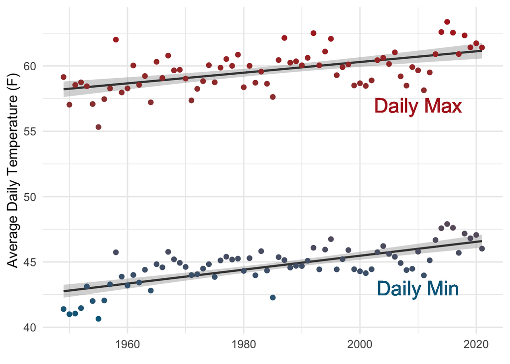

```r
# smooth yearly ggplot
ggplot(data = seattle_yearly) +
  geom_smooth(method = "lm",
              color = "gray25",
              aes(x = year,
                  y = mean_daily_max_temp)) +
  geom_smooth(method = "lm",
              color = "gray25",
              aes(x = year,
                  y = mean_daily_min_temp)) +
geom_point(aes(x = year,
               y = mean_daily_max_temp,
               color = mean_daily_max_temp),
           size = 2) +
  geom_point(aes(x = year,
                 y = mean_daily_min_temp,
                 color = mean_daily_min_temp),
             size = 2) +
  scale_color_gradientn(colors = c("deepskyblue4", "firebrick")) +
  theme_minimal(14) +
  theme(legend.position = "none") +
  labs(x = element_blank(),
       y = "Average Daily Temperature (F)") +
  geom_text(x = 2010, y = 57, label = "Daily Max", color = "firebrick", size = 7) +
  geom_text(x = 2010, y = 43, label = "Daily Min", color = "deepskyblue4", size = 7)
```

**Figure 1** shows Seattle’s average daily maximum temperature (red) and average daily minimum temperature (blue) by year. Trendline was fitted using simple linear regression. Grey shading represents the bounds of a 95% confidence interval.

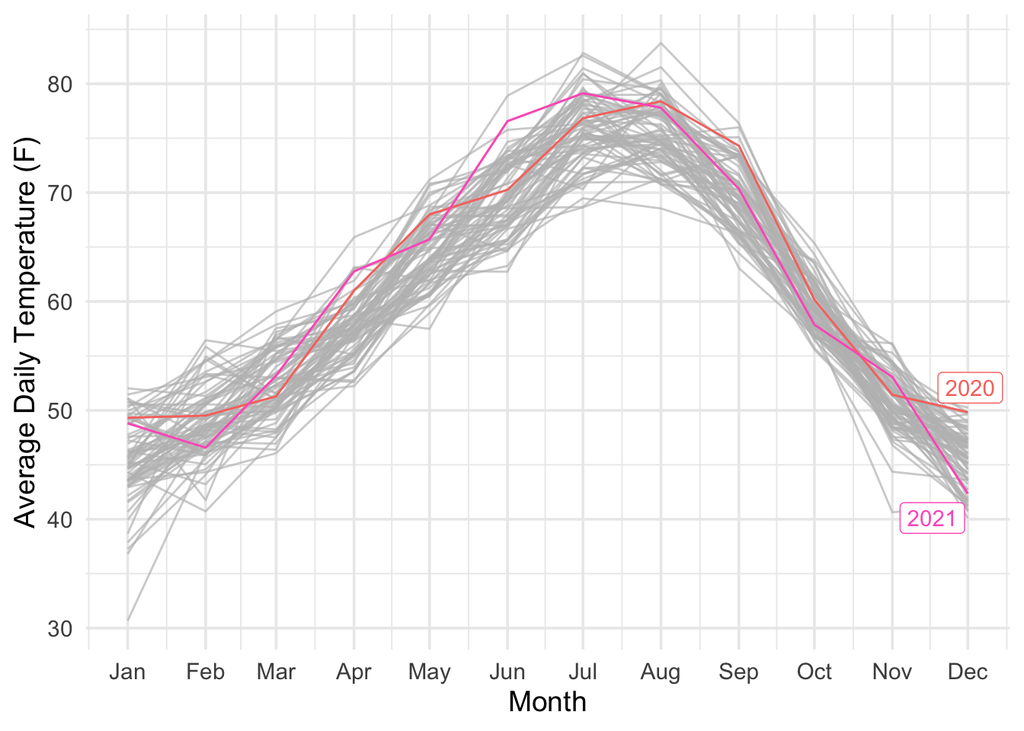

```r
# seasonplot
seattle_monthly %>%
  gg_season(y = mean_daily_max_temp) +
  gghighlight(year %in% c("2021", "2020")) +
  theme_minimal(14) +
  labs(x = "Month",
       y = "Average Daily Temperature (F)")
```

**Figure 2** shows seasonal variation in daily maximum temperature across from 1949-2021. Each grey line represents a year since 1949. The past two years are highlighted for reference.

### Precipitation

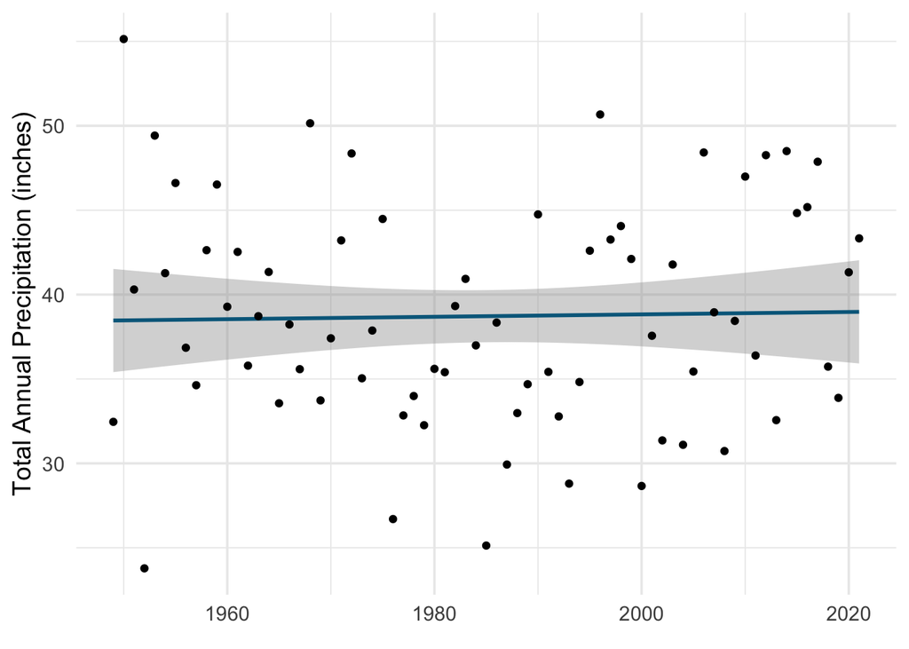

```r
ggplot(data = seattle_yearly, aes(x = year, y = total_yearly_precip)) +
  geom_smooth(method = "lm", color = "deepskyblue4") +
  geom_point() +
  theme_minimal(14) +
  labs(x = element_blank(), y = "Total Annual Precipitation (inches)")
```

**Figure 3** shows Seattle’s annual precipitation (inches) since 1949. Trendline was fitted using simple linear regression. Grey shading represents the bounds of a 95% confidence interval.

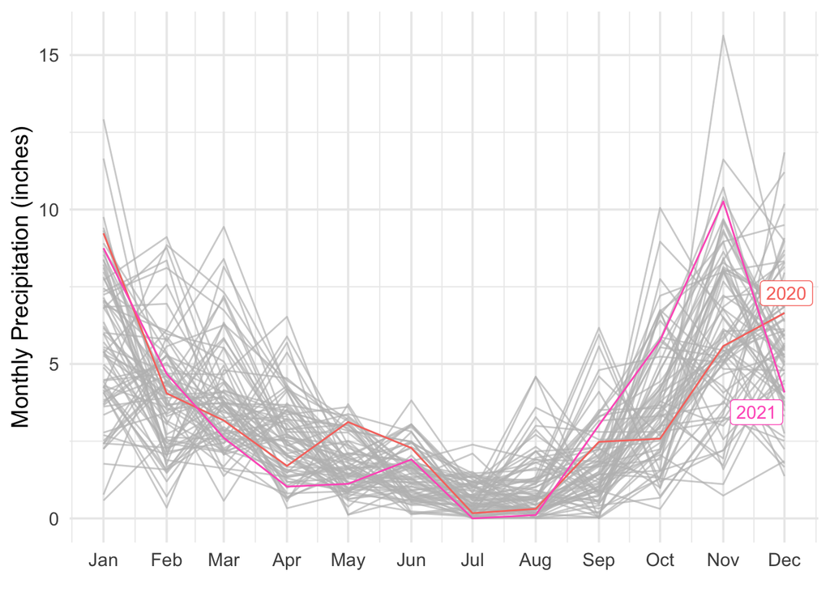

```r
seattle_monthly %>%
  gg_season(y = monthly_precip) +
  gghighlight(year %in% c("2021", "2020")) +
  theme_minimal(14) +
  labs(x = element_blank(), y = "Monthly Precipitation (inches)")
```

**Figure 4** shows seasonal variation in monthly precipitation totals. Each grey line represents a year from 1949-2021. The past two years are highlighted for reference.

### Statistical Testing

**Table 1** displays the results of statistical testing performed on the climate trends data. Slope and P value refer to the results of simple linear regression. M-K significance level refers to the results of Mann-Kendall test performed on each measure.

```r
# linear regressions

# max temp
temp_max_lm <- lm(mean_daily_max_temp ~ year, data = seattle_yearly)
temp_max_tidy <- tidy(temp_max_lm)

# min temp
temp_min_lm <- lm(mean_daily_min_temp ~ year, data = seattle_yearly)
temp_min_tidy <- tidy(temp_min_lm)

# annual precip
yearly_precip_lm <- lm(total_yearly_precip ~ year, data = seattle_yearly)
yearly_precip_tidy <- tidy(yearly_precip_lm)

# monthly precip
monthly_precip_lm <- lm(monthly_precip ~ year, data = seattle_monthly)
monthly_precip_tidy <- tidy(monthly_precip_lm)

lm_tidy_all <- rbind(temp_max_tidy,
                     temp_min_tidy,
                     yearly_precip_tidy,
                     monthly_precip_tidy)
lm_tidy_all_coef <- lm_tidy_all %>%
  filter(term == "year") %>%
  select(-statistic, -std.error, -term)

names_vector <- c("Average Maximum Daily Temperature (F)", "Average Minimum Daily Temperature (F)", "Annual Precipitation (inches)", "Monthly Precipitation (inches)")

lm_tidy_all_clean <- data.frame(names_vector, lm_tidy_all_coef)


# Mann Kendall testing for significance
mk1 <- MannKendall(seattle_yearly$mean_daily_max_temp)
mkt1 <- mk1$sl
mk2 <- MannKendall(seattle_yearly$mean_daily_min_temp)
mkt2 <- mk2$sl
mk3 <- MannKendall(seattle_yearly$total_yearly_precip)
mkt3 <- mk3$sl
mk4 <- MannKendall(seattle_monthly$monthly_precip)
mkt4 <- mk4$sl

mk_vector <- c(mkt1, mkt2, mkt3, mkt4)

stats_table <- data.frame(lm_tidy_all_clean, mk_vector)

kable(stats_table,
      col.names = c("Measurement", "Slope", "P value", "M-K Significance Level"),
      digits = c(0, 4, 4, 4)) %>%
  kable_minimal(full_width = FALSE)
```

| Measurement | Slope | P value | M-K Significance Level |
| --- | --- | --- | --- |
| Average Maximum Daily Temperature (F) | 0.0409 | 0.0000 | 0.0000 |
| Average Minimum Daily Temperature (F) | 0.0533 | 0.0000 | 0.0000 |
| Annual Precipitation (inches) | 0.0071 | 0.8471 | 0.8977 |
| Monthly Precipitation (inches) | 0.0005 | 0.9087 | 0.9896 |

#### Conclusions

- **Average daily maximum temperature is increasing on average by 0.04 degrees F per year**, and this trend was determined to be significant (p < 0.001).
- **Average daily minimum temperature is also increasing, on average by 0.05 degrees F**, and this trend was determined to be significant (p < 0.001).
- Thus temperatures both maximum and minimum daily average temperatures are increasing in the Seattle area.
- **There is not a significant trend in either monthly and annual precipitation**, indicating that precipitation levels are not changing over time in Seattle.

$$\\[.5in]$$

## Climate Extremes

```r
# Data wrangling

# Temperature

# hottest day of the year 1949-2021
seattle_hottest_days <- seattle_ts %>%
  index_by(year) %>%
  summarize(hottest_day = max(tmax)) %>%
  filter(year != "2022") %>%
  filter(year != "1948")

# days above 85 and days below freezing 1949-2021
seattle_hot_days <- seattle_ts %>%
  index_by(year) %>%
  summarize(days_above_85 = sum(ifelse(tmax >= 90, 1, 0))) %>%
  filter(year != "2022") %>%
  filter(year != "1948")

# days below freezing 1949-2021
seattle_below_freezing <- seattle_ts %>%
  index_by(year) %>%
  summarize(days_below_freezing = sum(ifelse(tmin <= 32, 1, 0))) %>%
  filter(year != "2022") %>%
  filter(year != "1948")
```

```r
# Data wrangling

# precipitation extremes

# days with over an inch of precipitation
seattle_wet_days <- seattle_ts %>%
  index_by(year) %>%
  summarize(wet_days = sum(ifelse(prcp >= 1, 1, 0))) %>%
  filter(year != "2022") %>%
  filter(year != "1948")

# days with no precipitation
seattle_dry_days <- seattle_ts %>%
  index_by(year) %>%
  summarize(dry_days = sum(ifelse(prcp < 0.1, 1, 0))) %>%
  filter(year != "2022") %>%
  filter(year != "1948")
```

### Temperature Extremes

[figure not shown]

```r
# plotting number of days over 85

ggplot(data = seattle_hot_days) +
  geom_smooth(method = "lm",
              color = "gray25",
              aes(x = year,
                  y = days_above_85)) +
geom_point(aes(x = year,
               y = days_above_85,
               color = days_above_85),
           size = 2) +
  scale_color_gradientn(colors = c("firebrick")) +
  theme_minimal(14) +
  theme(legend.position = "none") +
  labs(x = element_blank(),
       y = "Number of Days Over 85 Degrees (F)")
```

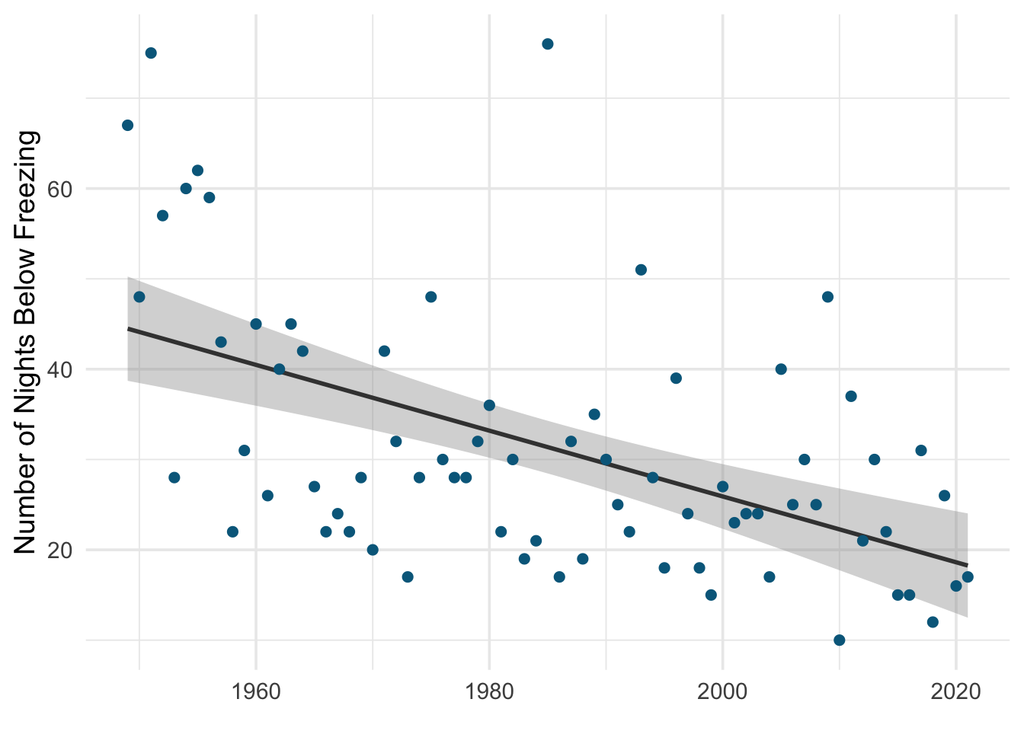

```r
# plotting number of days below freezing

ggplot(data = seattle_below_freezing) +
  geom_smooth(method = "lm",
              color = "gray25",
              aes(x = year,
                  y = days_below_freezing)) +
geom_point(aes(x = year,
               y = days_below_freezing,
               color = days_below_freezing),
           size = 2) +
  scale_color_gradientn(colors = c("deepskyblue4")) +
  theme_minimal(14) +
  theme(legend.position = "none") +
  labs(x = element_blank(),
       y = "Number of Nights Below Freezing")
```

**Figure 6** shows the number of days per year in Seattle where the minimum daily temperature dropped below freezing. The trendline was fitted using simple linear regression. Grey shading represents the bounds of a 95% confidence interval.

### Precipitation Extremes

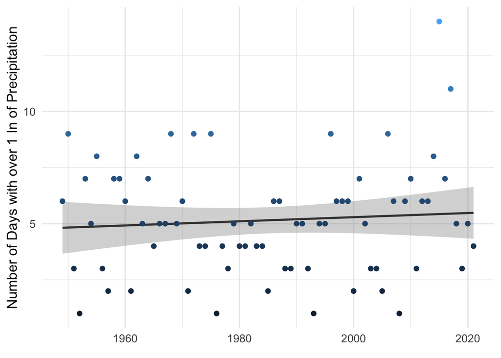

```r
ggplot(data = seattle_wet_days) +
  geom_smooth(method = "lm",
              color = "gray25",
              aes(x = year,
                  y = wet_days)) +
  geom_point(aes(x = year,
               y = wet_days,
               color = wet_days),
           size = 2) +
  theme_minimal(14) +
  theme(legend.position = "none") +
  labs(x = element_blank(),
       y = "Number of Days with over 1 In of Precipitation")
```

**Figure 7** shows the number of wet days in Seattle per year, determined by days with at least 1 inch of precipitation. The trendline was fitted using simple linear regression. Grey shading represents the bounds of a 95% confidence interval.

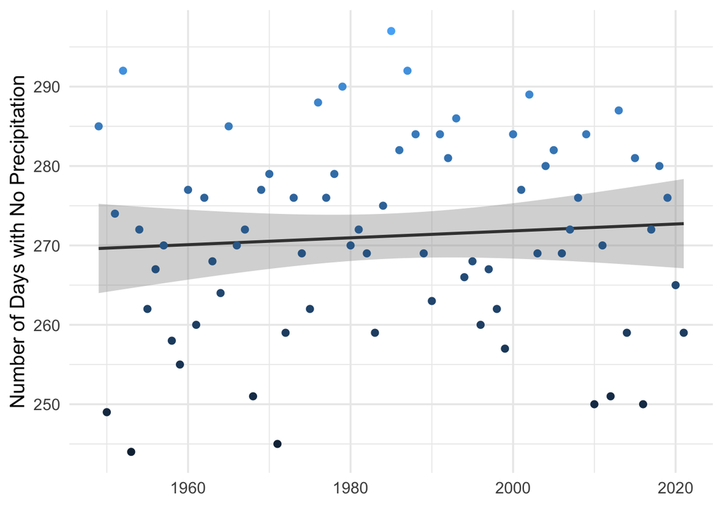

```r
ggplot(data = seattle_dry_days) +
  geom_smooth(method = "lm",
              color = "gray25",
              aes(x = year,
                  y = dry_days)) +
  geom_point(aes(x = year,
               y = dry_days,
               color = dry_days),
           size = 2) +
  theme_minimal(14) +
  theme(legend.position = "none") +
  labs(x = element_blank(),
       y = "Number of Days with No Precipitation")
```

### Statistical Testing

**Table 2** shows the results of statistical testing performed on the climate extremes data. Slope and P value refer to the results of simple linear regression. M-K significance level refers to the results of Mann-Kendall test performed on each measure.

```r
# linear regressions

# hot days
hot_days_lm <- lm(days_above_85 ~ year, data = seattle_hot_days)
hot_days_tidy <- tidy(hot_days_lm)

# freezing days
freezing_days_lm <- lm(days_below_freezing ~ year, data = seattle_below_freezing)
freezing_days_tidy <- tidy(temp_min_lm)

# wet days
wet_days_lm <- lm(wet_days ~ year, data = seattle_wet_days)
wet_days_tidy <- tidy(wet_days_lm)

# dry days
dry_days_lm <- lm(dry_days ~ year, data = seattle_dry_days)
dry_days_tidy <- tidy(dry_days_lm)

lm_tidy_extremes <- rbind(hot_days_tidy,
                     freezing_days_tidy,
                     wet_days_tidy,
                     dry_days_tidy)
lm_tidy_extremes_coef <- lm_tidy_extremes %>%
  filter(term == "year") %>%
  select(-statistic, -std.error, -term)

extremes_names_vector <- c("Days Per Year Above 85 Degrees (F)", "Days Per Year Below Freezing", "Number of Days with over 1 Inch of Precipitation", "Number of Days with No Precipitation")

lm_tidy_extremes_clean <- data.frame(extremes_names_vector, lm_tidy_extremes_coef)


# Mann Kendall testing for significance
mk_hot_days <- MannKendall(seattle_hot_days$days_above_85)
mkt_hot_days <- mk_hot_days$sl
mk_freezing_days <- MannKendall(seattle_below_freezing$days_below_freezing)
mkt_freezing_days <- mk_freezing_days$sl
mk_wet_days <- MannKendall(seattle_wet_days$wet_days)
mkt_wet_days <- mk_wet_days$sl
mk_dry_days <- MannKendall(seattle_dry_days$dry_days)
mkt_dry_days <- mk_dry_days$sl

mk_extremes_vector <- c(mkt_hot_days, mkt_freezing_days, mkt_wet_days, mkt_dry_days)

extremes_stats_table <- data.frame(lm_tidy_extremes_clean, mk_extremes_vector)

kable(extremes_stats_table,
      col.names = c("Measurement", "Slope", "P value", "M-K Significance Level"),
      digits = c(0, 4, 4, 4)) %>%
  kable_minimal(full_width = FALSE)
```

[output not shown]

## Discussion

The analyses conducted in this report show that average maximum and minimum temperatures are increasing over time; and that extreme heat events are increasing in frequency while extreme cold events are decreasing. While these trends in temperature were found to be significant, no significant changes in precipitation trends or extremes were observed. These results indicate that Seattle will need to adapt to increasing temperatures and extreme heat events as global temperatures rise due to climate change.

The conclusions from this analysis suggest that Seattle should prepare for warmer average temperatures and more frequent heat waves. The city may want to consider adaptation measures that can reduce urban heat island effects such as high albedo rooftops, cool pavements, and an increase of tree cover and vegetation. However, careful research and planning should accompany these investments as seemingly beneficial adaptation practices such as increasing tree cover have been shown to increase gentrification, raising equity concerns.